# Jaleel Walter Henry Savoy

## Data Analysis Assignment 8 - Classification Methods

## Introduction

The objective of this report is to analyze weekly stock index return data to fit classification models that predict whether the weekly return direction will be positive or negative. There are many classification varieties, but for this report, there will be four classification methods fitted, explored, and compared (based on classification performance measures): logistic regression, linear discriminant analysis, quadratic discriminant analysis, and k-Nearest Neighbors classification.

## Data Source

The data set for this analysis will be the Weekly S&P Stock Market Data that is built into the ISLR library in R and it contains weekly percent return values, weekly shares volume, and weekly directional movement for the S&P 500 index; the data set has 1089 observations (weeks) and 9 variables. The data was collected from each week between 1990 and 2010, and the weekly percentage returns were calculated based on raw data collected from Yahoo Finance.

Data set features:

| Variable Name | Description | Data type |
| --- | --- | --- |
| Year | Year the observation was recorded | Integer |
| Lag1 | Return for 1 week ago (percentage) | Float |
| Lag2 | Return for 2 weeks ago (percentage) | Float |
| Lag3 | Return for 3 weeks ago (percentage) | Float |
| Lag4 | Return for 4 weeks ago (percentage) | Float |
| Lag5 | Return for 5 weeks ago (percentage) | Float |
| Volume | Shares Volume (daily average) in billions | Float |
| Today | Return for the current week (percentage) | Float |
| Direction | Directional movement return for the week | Categorical (2 levels) |

Since the goal is to accurately predict a given week's direction, not the week's exact percent return, then the response would be the Direction feature and the predictors would be the lagged percent return features and the lagged volume feature.

## Methods Overview

### Logistic Regression

Logistic regression is a discriminative modeling approach to classification. This method directly estimates the posterior, conditional probabilities of class membership given the values for predictor features. When using logistic regression, the assumption is that the posterior, conditional probabilities given a set of predictors is a nonlinear function of the predictor variables. This method learns a linear decision boundary.

### Linear Discriminant Analysis

In contrast to logistic regression, linear discriminant analysis is a generative modeling approach to classification that estimates the intra-class densities of the predictor variables given the classes, and that is then used in the Bayes formula to estimate the posterior, conditional probabilities of class membership given predictors. There are two main assumptions for this method; each class is assumed to have an identical covariance matrix and the intra-class densities are assumed to be normal (Gaussian) distributions. Often, this method performs similarly to logistic regression, but there are situations where it can outperform or underperform in comparison to logistic regression; the assumption of normally distributed intra-class densities can have a large impactful on linear discriminant analysis performance. This method learns a linear decision boundary.

### Quadratic Discriminant Analysis

Quadratic discriminant analysis is essentially the same as linear discriminant analysis, but instead of being able to only learn linear decision boundaries it can learn quadratic decision boundaries. The ability to learn quadratic decision boundaries allows quadratic discriminant analysis to be more flexible than logistic regression and linear discriminant analysis. Additionally, the quadratic discriminant analysis does not have the assumption of identical covariance matrices for each class. The increased flexibility offered by the method also results in a higher variance than the less flexible methods.

### k-Nearest Neighbors Classification

In contrast to the previous three methods, which were parametric, k-Nearest Neighbors classification is a non-parametric classification method that makes no assumptions about the functional form of the classifier. The model identifies a certain number of the closest observations, k, and it then it predicts the class membership based on the class that has the largest proportion in the k-sized neighborhood. The decision boundary can be smoothed by increasing the size of the neighborhood or be rougher by decreasing the size of the neighborhood; the method loses flexibility as k increases. This method is the most flexible of the four classification approaches explored in this report, but this has potential downsides. As mentioned before, increased flexibility results in higher variance than less flexible methods.

## Exploratory Data Analysis

Before performing fitting and analyzing models, it is important to explore the data to understand the structure of the data and the relationships among the features. For this report, the data exploration was done with both numerical and graphical summaries of the data.

**Note: The Volume feature had to be lagged to prevent signal leakage**

## Classification Models

For this section of the report, two models were fitted for each classification method; once with just the Lag2 feature and once with a subset of the features, including transformations of the features. The goal is to compare models and identify, which method performed best at accurately predicting whether the weekly percent return was positive or negative for a given week based on the lagged features and possible transformations.

For the training and testing, all observations before 2009 were used for training and all observations after 2009 were used for testing, which resulted in a about 90% of the data being used for training and about 10% of the data being used for testing.

**Note: The associated confusion matrix for each model is located in their respective appendix section**

### Logistic Regression

#### Model Fit with Only Lag2

Predictor: Lag2

| Classification Measure | Test Performance |
| --- | --- |
| Correct Classification Rate | 0.625 |
| Misclassification Rate | 0.375 |
| Specificity | 0.209302325581395 |
| Sensitvity | 0.918032786885246 |
| Positive Predictive Value | 0.622222222222222 |
| Negative Predictive Value | 0.642857142857143 |

#### Model Fit with Multiple Predictors

| Classification Measure | Test Performance |
| --- | --- |
| Correct Classification Rate | 0.615384615384615 |
| Misclassification Rate | 0.384615384615385 |
| Specificity | 0.604651162790698 |
| Sensitvity | 0.622950819672131 |
| Positive Predictive Value | 0.690909090909091 |
| Negative Predictive Value | 0.530612244897959 |

### Linear Discriminant Analysis

#### Model Fit with Only Lag2

Predictor: Lag2

[output not shown]

#### Model Fit with Multiple Predictors

| Classification Measure | Test Performance |
| --- | --- |
| Correct Classification Rate | 0.625 |
| Misclassification Rate | 0.375 |
| Specificity | 0.604651162790698 |
| Sensitvity | 0.639344262295082 |
| Positive Predictive Value | 0.696428571428571 |
| Negative Predictive Value | 0.541666666666667 |

### Quadratic Discriminant Analysis

#### Model Fit with Only Lag2

Predictor: Lag2

| Classification Measure | Test Performance |
| --- | --- |
| Correct Classification Rate | 0.586538461538462 |
| Misclassification Rate | 0.413461538461538 |
| Specificity | 0.00 |
| Sensitvity | 1.00 |
| Positive Predictive Value | 0.586538461538462 |
| Negative Predictive Value | NaN |

#### Model Fit with Multiple Predictors

| Classification Measure | Test Performance |
| --- | --- |
| Correct Classification Rate | 0.615384615384615 |
| Misclassification Rate | 0.384615384615385 |
| Specificity | 0.674418604651163 |
| Sensitvity | 0.573770491803279 |
| Positive Predictive Value | 0.714285714285714 |
| Negative Predictive Value | 0.527272727272727 |

### k-Nearest Neighbors Classification

#### Model Fit with Only Lag2

Predictor: Lag2

| Classification Measure | Test Performance |
| --- | --- |
| Correct Classification Rate | 0.471153846153846 |
| Misclassification Rate | 0.528846153846154 |
| Specificity | 0.325581395348837 |
| Sensitvity | 0.573770491803279 |
| Positive Predictive Value | 0.546875 |
| Negative Predictive Value | 0.35 |

#### Model Fit with Multiple Predictors

Predictors: Volume.Lag4, Volume.Lag5, the squared-difference between Lag1 and Lag5, the difference between Lag1 and Lag2, and the difference between Lag1 and Lag4

| Classification Measure | Test Performance |
| --- | --- |
| Correct Classification Rate | 0.653846153846154 |
| Misclassification Rate | 0.346153846153846 |
| Specificity | 0.697674418604651 |
| Sensitvity | 0.622950819672131 |
| Positive Predictive Value | 0.745098039215686 |
| Negative Predictive Value | 0.566037735849057 |

## Comparing Results

The k-Nearest Neighbors classification model with Lag2 as the sole predictor performed poorly. The model had a larger misclassification rate than a correct classification rate on test data, it had a very poor specificity measure, and it had a poor negative predictive value. The second model was fit with the following predictors: Volume.Lag4, Volume.Lag5, the squared-difference between Lag1 and Lag5, the difference between Lag1 and Lag2, and the difference between Lag1 and Lag4. This model was a drastic improvement over the previous one. This model decreased the misclassification rate by about 18%, more than doubled the specificity measure, increased the sensitivity measure, increased the positive predictive value by about 20%, and increased the negative predictive value by about 21%.

Overall, the second k-Nearest Neighbors model performed the best, which is supported by its classification measures; it has the smallest misclassification rate and it is able to fairly accurately predict both the Up and Down classes. The runner-up model would be the second quadratic discriminant analysis model. In regards to models fitted using only the Lag2 predictor, the best models for that were the logistic regression and the linear discriminant analysis model.

## Conclusions

The second k-Nearest Neighbors classification model and the second quadratic discriminant analysis model would both be suitable models to address the research focus of this report, which is to accurately predict the weekly movements of the S&P 500 index lagged percentage returns and lagged trade volumes. There is clearly room for improvement across all of the models. Additionally, more features would also be useful; using only lagged values of two features is pretty restrictive.

## Citations

Hadley Wickham (2017). tidyverse: Easily Install and Load the 'Tidyverse'. R package version 1.2.1. https://CRAN.R-project.org/package=tidyverse

James, G., Witten, D., Hastie, T., and Tibshirani, R (2017). ISLR: Data for an Introduction to Statistical Learning with Applications in R. R package version 1.2. https://CRAN.R-project.org/package=ISLR

Venables, W. N. & Ripley, B. D. (2002) Modern Applied Statistics with S. Fourth Edition. Springer, New York. ISBN 0-387-95457-0

## Appendix

```
      Year           Lag1               Lag2               Lag3
 Min.   :1990   Min.   :-18.1950   Min.   :-18.1950   Min.   :-18.1950
 1st Qu.:1995   1st Qu.: -1.1540   1st Qu.: -1.1540   1st Qu.: -1.1580
 Median :2000   Median :  0.2410   Median :  0.2410   Median :  0.2410
 Mean   :2000   Mean   :  0.1506   Mean   :  0.1511   Mean   :  0.1472
 3rd Qu.:2005   3rd Qu.:  1.4050   3rd Qu.:  1.4090   3rd Qu.:  1.4090
 Max.   :2010   Max.   : 12.0260   Max.   : 12.0260   Max.   : 12.0260
      Lag4               Lag5              Volume            Today
 Min.   :-18.1950   Min.   :-18.1950   Min.   :0.08747   Min.   :-18.1950
 1st Qu.: -1.1580   1st Qu.: -1.1660   1st Qu.:0.33202   1st Qu.: -1.1540
 Median :  0.2380   Median :  0.2340   Median :1.00268   Median :  0.2410
 Mean   :  0.1458   Mean   :  0.1399   Mean   :1.57462   Mean   :  0.1499
 3rd Qu.:  1.4090   3rd Qu.:  1.4050   3rd Qu.:2.05373   3rd Qu.:  1.4050
 Max.   : 12.0260   Max.   : 12.0260   Max.   :9.32821   Max.   : 12.0260
 Direction
 Down:484
 Up  :605
```

| Year | Lag1 | Lag2 | Lag3 | Lag4 | Lag5 | Volume | Today | Direction |
| --- | --- | --- | --- | --- | --- | --- | --- | --- |
| 1990 | 0.816 | 1.572 | -3.936 | -0.229 | -3.484 | 0.1549760 | -0.270 | Down |
| 1990 | -0.270 | 0.816 | 1.572 | -3.936 | -0.229 | 0.1485740 | -2.576 | Down |
| 1990 | -2.576 | -0.270 | 0.816 | 1.572 | -3.936 | 0.1598375 | 3.514 | Up |
| 1990 | 3.514 | -2.576 | -0.270 | 0.816 | 1.572 | 0.1616300 | 0.712 | Up |
| 1990 | 0.712 | 3.514 | -2.576 | -0.270 | 0.816 | 0.1537280 | 1.178 | Up |

|  | Year | Lag1 | Lag2 | Lag3 | Lag4 | Lag5 | Volume | Today | Direction |
| --- | --- | --- | --- | --- | --- | --- | --- | --- | --- |
| 314 | 1996 | 3.229 | 2.288 | 1.600 | 1.665 | -2.416 | 0.451808 | -1.278 | Down |
| 858 | 2006 | 0.331 | -2.314 | -0.372 | 2.065 | -0.563 | 2.475962 | 3.085 | Up |
| 445 | 1998 | -2.451 | -2.786 | -1.765 | -3.872 | 1.926 | 0.674002 | 1.740 | Up |
| 959 | 2008 | -3.001 | -3.096 | -0.048 | -2.835 | 1.777 | 5.031320 | -1.211 | Down |
| 1021 | 2009 | -1.218 | 0.273 | 2.195 | -0.632 | 2.329 | 5.286260 | 2.591 | Up |

|  | Year | Lag1 | Lag2 | Lag3 | Lag4 | Lag5 | Volume | Today | Direction |
| --- | --- | --- | --- | --- | --- | --- | --- | --- | --- |
| 1085 | 2010 | -0.861 | 0.043 | -2.173 | 3.599 | 0.015 | 3.205160 | 2.969 | Up |
| 1086 | 2010 | 2.969 | -0.861 | 0.043 | -2.173 | 3.599 | 4.242568 | 1.281 | Up |
| 1087 | 2010 | 1.281 | 2.969 | -0.861 | 0.043 | -2.173 | 4.835082 | 0.283 | Up |
| 1088 | 2010 | 0.283 | 1.281 | 2.969 | -0.861 | 0.043 | 4.454044 | 1.034 | Up |
| 1089 | 2010 | 1.034 | 0.283 | 1.281 | 2.969 | -0.861 | 2.707105 | 0.069 | Up |

|  | Lag1 | Lag2 | Lag3 | Lag4 | Lag5 | Volume | Volume.Lag2 | Volume.Lag3 | Volume.Lag4 | Volume.Lag5 | Sequence |
| --- | --- | --- | --- | --- | --- | --- | --- | --- | --- | --- | --- |
| Lag1 | 1.000000000 | -0.07485305 | 0.05863568 | -0.07127388 | -0.008183096 | -0.03329107 | -0.03413513 | -0.02967397 | -0.04323685 | -0.01155594 | -0.03157687 |
| Lag2 | -0.074853051 | 1.00000000 | -0.07572091 | 0.05838153 | -0.072499482 | -0.06568041 | -0.03282026 | -0.03522141 | -0.03052296 | -0.04431387 | -0.03312914 |
| Lag3 | 0.058635682 | -0.07572091 | 1.00000000 | -0.07539587 | 0.060657175 | -0.08393055 | -0.03304462 | -0.03140647 | -0.03375179 | -0.02911273 | -0.03041998 |
| Lag4 | -0.071273876 | 0.05838153 | -0.07539587 | 1.00000000 | -0.075675027 | -0.06944146 | -0.06507341 | -0.03364168 | -0.03170804 | -0.03433361 | -0.03093453 |
| Lag5 | -0.008183096 | -0.07249948 | 0.06065717 | -0.07567503 | 1.000000000 | -0.06045949 | -0.08553796 | -0.06553855 | -0.03339813 | -0.03212810 | -0.03038177 |
| Volume | -0.033291072 | -0.06568041 | -0.08393055 | -0.06944146 | -0.060459489 | 1.00000000 | 0.96061620 | 0.95342406 | 0.94712851 | 0.94454681 | 0.84234781 |
| Volume.Lag2 | -0.034135128 | -0.03282026 | -0.03304462 | -0.06507341 | -0.085537964 | 0.96061620 | 1.00000000 | 0.97438669 | 0.96092573 | 0.95359475 | 0.84141818 |
| Volume.Lag3 | -0.029673971 | -0.03522141 | -0.03140647 | -0.03364168 | -0.065538552 | 0.95342406 | 0.97438669 | 1.00000000 | 0.97453917 | 0.96086774 | 0.84100812 |
| Volume.Lag4 | -0.043236848 | -0.03052296 | -0.03375179 | -0.03170804 | -0.033398131 | 0.94712851 | 0.96092573 | 0.97453917 | 1.00000000 | 0.97467457 | 0.84096305 |
| Volume.Lag5 | -0.011555941 | -0.04431387 | -0.02911273 | -0.03433361 | -0.032128105 | 0.94454681 | 0.95359475 | 0.96086774 | 0.97467457 | 1.00000000 | 0.84056221 |
| Sequence | -0.031576872 | -0.03312914 | -0.03041998 | -0.03093453 | -0.030381769 | 0.84234781 | 0.84141818 | 0.84100812 | 0.84096305 | 0.84056221 | 1.00000000 |

```
Down   Up
 484  605
```

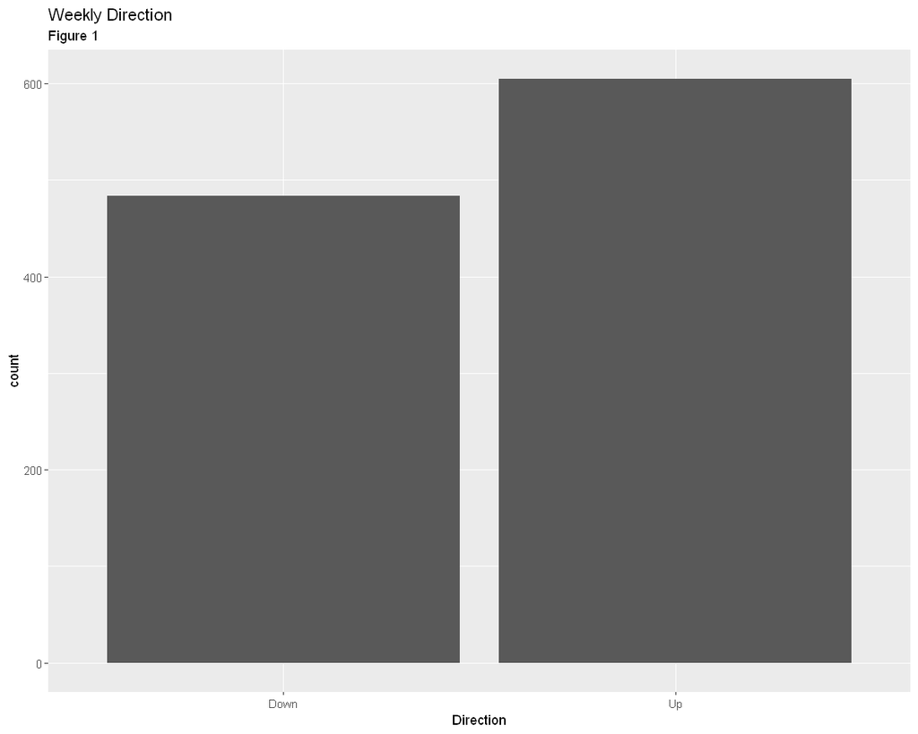

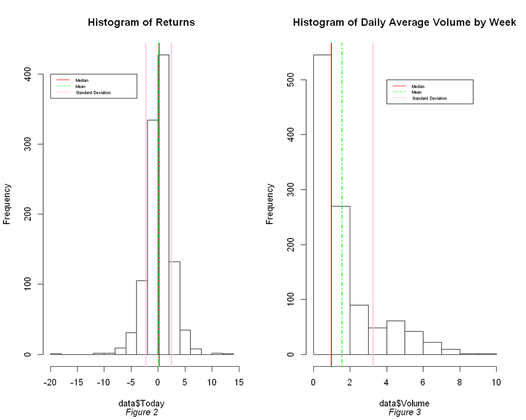

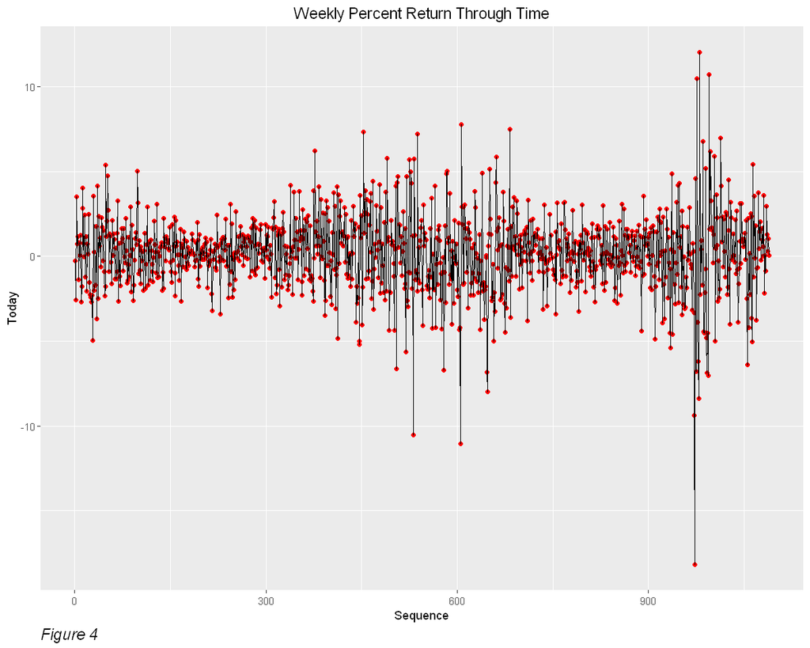

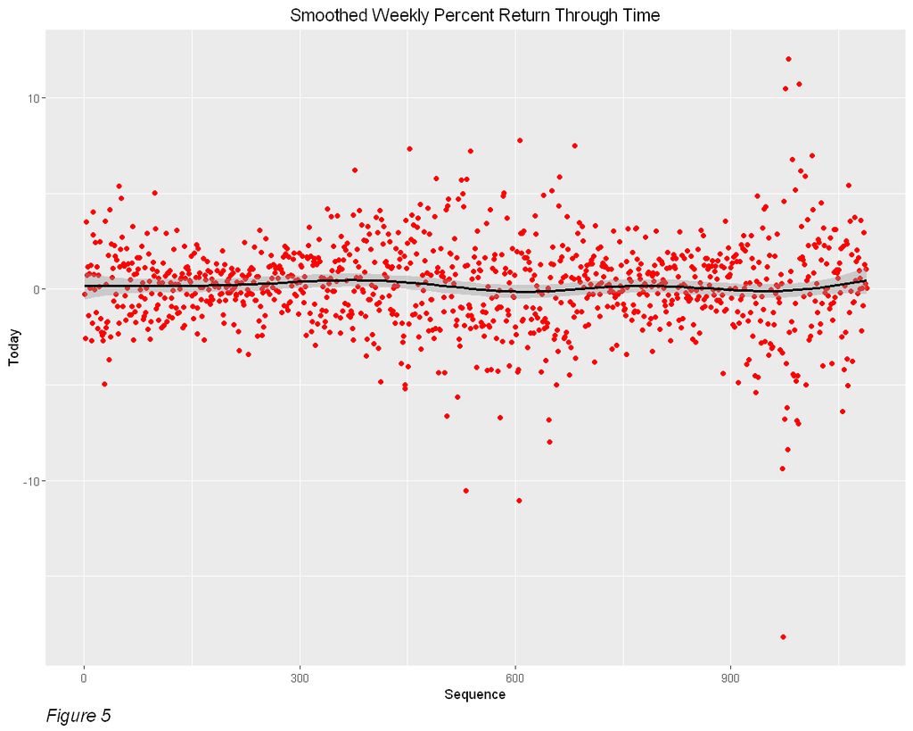

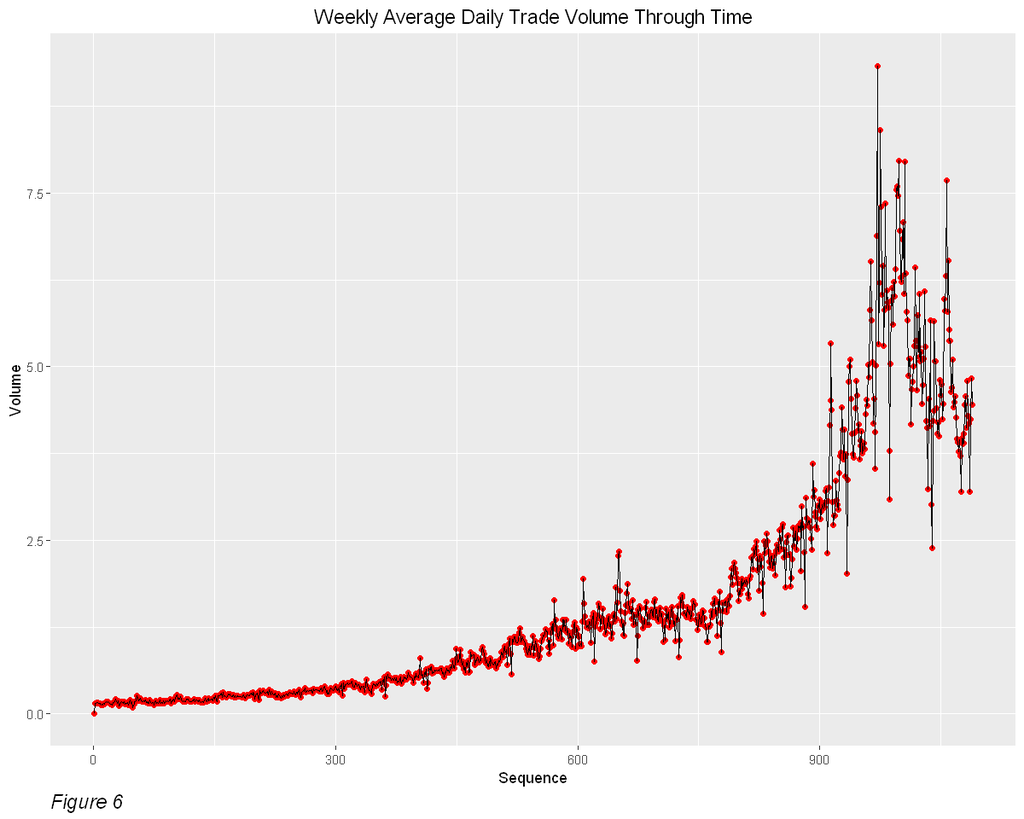

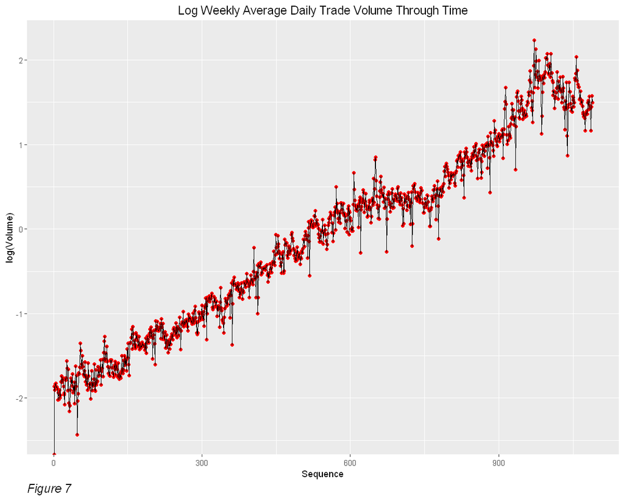

```r
#################################################################################################
# Appendix: Exploratory Data Analysis
#################################################################################################
options(repr.plot.width=10, repr.plot.height=8)
par(mfrow=c(1,2))

## set Seed for reproducibility
set.seed(123)

## import relevant packages
suppressPackageStartupMessages(library(ISLR, warn.conflicts=FALSE))
suppressPackageStartupMessages(library(tidyverse, warn.conflicts=FALSE))
suppressPackageStartupMessages(library(corrplot, warn.conflicts=FALSE))
suppressPackageStartupMessages(library(MASS, warn.conflicts=FALSE))
suppressPackageStartupMessages(library(class, warn.conflicts=FALSE))
suppressPackageStartupMessages(library(glmnet, warn.conflicts=FALSE))

## create initial data frame
data <- Weekly

## view data summary
summary(data)

## preview the first 5 rows
head(data, 5)

## preview 10 random rows
(data[sample(nrow(data), 5), ])

## preview the last 5 rows
tail(data, 5)

## lag the Volume column
data$Volume <- lag(data$Volume, 1)
data$Volume[is.na(data$Volume)] <- 0
data$Volume.Lag2 <- lag(data$Volume, 2)
data$Volume.Lag2[is.na(data$Volume.Lag2)] <- 0
data$Volume.Lag3 <- lag(data$Volume, 3)
data$Volume.Lag3[is.na(data$Volume.Lag3)] <- 0
data$Volume.Lag4 <- lag(data$Volume, 4)
data$Volume.Lag4[is.na(data$Volume.Lag4)] <- 0
data$Volume.Lag5 <- lag(data$Volume, 5)
data$Volume.Lag5[is.na(data$Volume.Lag5)] <- 0

## differences between lags
data$diff.lag1.lag2 <- (data$Lag1 - data$Lag2)
data$diff.lag1.lag3 <- (data$Lag1 - data$Lag3)
data$diff.lag1.lag4 <- (data$Lag1 - data$Lag4)
data$diff.lag1.lag5 <- (data$Lag1 - data$Lag5)
data$diff.lag2.lag3 <- (data$Lag2 - data$Lag2)
data$diff.lag2.lag4 <- (data$Lag2 - data$Lag4)
data$diff.lag2.lag5 <- (data$Lag2 - data$Lag5)
data$diff.lag3.lag4 <- (data$Lag3 - data$Lag4)
data$diff.lag3.lag5 <- (data$Lag3 - data$Lag5)
data$diff.lag4.lag5 <- (data$Lag4 - data$Lag5)

## squared-differences between lags
data$sq.diff.lag1.lag2 <- (data$Lag1 - data$Lag2)**2
data$sq.diff.lag1.lag3 <- (data$Lag1 - data$Lag3)**2
data$sq.diff.lag1.lag4 <- (data$Lag1 - data$Lag4)**2
data$sq.diff.lag1.lag5 <- (data$Lag1 - data$Lag5)**2
data$sq.diff.lag2.lag3 <- (data$Lag2 - data$Lag2)**2
data$sq.diff.lag2.lag4 <- (data$Lag2 - data$Lag4)**2
data$sq.diff.lag2.lag5 <- (data$Lag2 - data$Lag5)**2
data$sq.diff.lag3.lag4 <- (data$Lag3 - data$Lag4)**2
data$sq.diff.lag3.lag5 <- (data$Lag3 - data$Lag5)**2
data$sq.diff.lag4.lag5 <- (data$Lag4 - data$Lag5)**2

## volume multiplied by percent return lags
data$vol.lag.1 <- data$Lag1 * data$Volume
data$vol.lag.2 <- data$Lag2 * data$Volume.Lag2
data$vol.lag.3 <- data$Lag3 * data$Volume.Lag3
data$vol.lag.4 <- data$Lag4 * data$Volume.Lag4
data$vol.lag.5 <- data$Lag5 * data$Volume.Lag5

## get the sequence order
data$Sequence <- as.integer(row.names(data))

## get the training and test sets
training <- data$Year < 2009
test.data <- data[!training,]
train.data <- data[training,]
train.data$Today <- NULL
# train.data$Sequence <- NULL


## predictors and Response
predictors <- c("Lag1","Lag2","Lag3","Lag4","Lag5", "Volume",'Volume.Lag2', 'Volume.Lag3', 'Volume.Lag4',
                'Volume.Lag5','Sequence')
response   <- "Direction"

## Correlation of the variables
(cor(data[predictors]))

## check the proportion of the responses
(table(data$Direction))
ggplot(data,aes(x = Direction)) +
    geom_bar() +
    labs(title = "Weekly Direction", subtitle = "Figure 1")

# histogram of the Weekly Return Percentages
hist(data$Today, main="Histogram of Returns", sub=expression(paste(italic("Figure 2"))))
abline(v=median(data$Today), col='red', lty='solid', lwd=2)
abline(v=mean(data$Today), col='green', lty='dotdash', lwd=2)
abline(v=mean(data$Today)+sd(data$Today), col='pink', lty='solid', lwd=1.75)
abline(v=mean(data$Today)-sd(data$Today), col='pink', lty='solid', lwd=1.75)
legend(-20,400,legend=c("Median", "Mean", "Standard Deviation"),
       col=c("red", "green", 'pink'), lty=c('solid', 'dotdash', 'solid'), cex=0.45)

# histogram of daily average volume by week
hist(data$Volume, main="Histogram of Daily Average Volume by Week", sub=expression(paste(italic("Figure 3"))))
abline(v=median(data$Volume), col='red', lty='solid', lwd=2)
abline(v=mean(data$Volume), col='green', lty='dotdash', lwd=2)
abline(v=mean(data$Volume)+sd(data$Volume), col='pink', lty='solid', lwd=1.75)
legend(4,500,legend=c("Median", "Mean", "Standard Deviation"),
       col=c("red", "green", 'pink'), lty=c('solid', 'dotdash', 'solid'), cex=0.45)

# Visualize Weekly returns and weekly volume across time
ggplot(data, aes(x = Sequence, y = Today)) +
    geom_point(col="red") +
    geom_line(col="black") +
    labs(title="Weekly Percent Return Through Time",caption="Figure 4") +
    theme(
        plot.title = element_text(hjust = 0.5, size = 14),
        plot.subtitle = element_text(hjust = 0.5),
        plot.caption = element_text(hjust = 0, face = "italic", size=14))

ggplot(data, aes(x = Sequence, y = Today)) +
    geom_point(col="red") +
    geom_smooth(method="auto",col="black") +
    labs(title="Smoothed Weekly Percent Return Through Time",caption="Figure 5") +
    theme(
        plot.title = element_text(hjust = 0.5, size = 14),
        plot.subtitle = element_text(hjust = 0.5),
        plot.caption = element_text(hjust = 0, face = "italic", size=14))

ggplot(data, aes(x = Sequence, y = Volume)) +
    geom_point(col="red") +
    geom_line(col="black") +
    labs(title="Weekly Average Daily Trade Volume Through Time",caption="Figure 6") +
    theme(
        plot.title = element_text(hjust = 0.5, size = 14),
        plot.subtitle = element_text(hjust = 0.5),
        plot.caption = element_text(hjust = 0, face = "italic", size=14))

ggplot(data, aes(x = Sequence, y = log(Volume))) +
    geom_point(col="red") +
    geom_line(col="black") +
    labs(title="Log Weekly Average Daily Trade Volume Through Time",caption="Figure 7") +
    theme(
        plot.title = element_text(hjust = 0.5, size = 14),
        plot.subtitle = element_text(hjust = 0.5),
        plot.caption = element_text(hjust = 0, face = "italic", size=14))
```

```r
#################################################################################################
# Appendix: Logistic Regression - Using hold-out validation set and just Lag2 predictor
#################################################################################################
## Fit model
logistic.regression <- glm(Direction∼Lag2,
                           data=train.data, family=binomial)
# Summary
(summary(logistic.regression))

# Training Prediction
logistic.prediction.probs <- predict(logistic.regression, type="response")
logistic.predictions <- rep("Down",nrow(train.data))
logistic.predictions[logistic.prediction.probs>.5]="Up"

# Testing Prediction
logistic.prediction.probs.2 <- predict(logistic.regression, test.data, type="response")
logistic.predictions.2 <- rep("Down",nrow(test.data))
logistic.predictions.2[logistic.prediction.probs.2>.5]="Up"

# Testing Confusion matrix
(test.table <- table("Actual"=test.data$Direction, "Preds"=logistic.predictions.2))

# Classificaiton metrics
paste("Testing - Correct Classification Rate: ", (test.table[1,1]+test.table[2,2])/(nrow(test.data)))
paste("Testing - Misclassification Rate: ", 1-(test.table[1,1]+test.table[2,2])/(nrow(test.data)))
paste("Testing - Specificity: ", (test.table[1,1])/(test.table[1,1]+test.table[1,2]))
paste("Testing - Sensitvity: ", (test.table[2,2])/(test.table[2,2]+test.table[2,1]))
paste("Testing - Positive Predictive Value: ", (test.table[2,2])/(test.table[1,2]+test.table[2,2]))
paste("Testing - Negative Predictive Value: ", (test.table[1,1])/(test.table[1,1]+test.table[2,1]))
```

```
Call:
glm(formula = Direction ~ Lag2, family = binomial, data = train.data)

Deviance Residuals:
   Min      1Q  Median      3Q     Max
-1.536  -1.264   1.021   1.091   1.368

Coefficients:
            Estimate Std. Error z value Pr(>|z|)
(Intercept)  0.20326    0.06428   3.162  0.00157 **
Lag2         0.05810    0.02870   2.024  0.04298 *
---
Signif. codes:  0 '***' 0.001 '**' 0.01 '*' 0.05 '.' 0.1 ' ' 1

(Dispersion parameter for binomial family taken to be 1)

    Null deviance: 1354.7  on 984  degrees of freedom
Residual deviance: 1350.5  on 983  degrees of freedom
AIC: 1354.5

Number of Fisher Scoring iterations: 4
```

```
      Preds
Actual Down Up
  Down    9 34
  Up      5 56
```

'Testing - Correct Classification Rate: 0.625'

'Testing - Misclassification Rate: 0.375'

'Testing - Specificity: 0.209302325581395'

'Testing - Sensitvity: 0.918032786885246'

'Testing - Positive Predictive Value: 0.622222222222222'

'Testing - Negative Predictive Value: 0.642857142857143'

```
Call:
lda(Direction ~ Lag2, data = train.data)

Prior probabilities of groups:
     Down        Up
0.4477157 0.5522843

Group means:
            Lag2
Down -0.07205722
Up    0.05841404

Coefficients of linear discriminants:
          LD1
Lag2 1.001604
```

'Prior, unconditioned probability of Down: 0.447715736040609'

'Prior, unconditioned probability of Up: 0.552284263959391'

```
      Preds
Actual Down Up
  Down    4 39
  Up      2 59
```

'Testing - Correct Classification Rate: 0.605769230769231'

'Testing - Misclassification Rate: 0.394230769230769'

'Testing - Specificity: 0.0930232558139535'

'Testing - Sensitvity: 0.967213114754098'

'Testing - Positive Predictive Value: 0.602040816326531'

'Testing - Negative Predictive Value: 0.666666666666667'

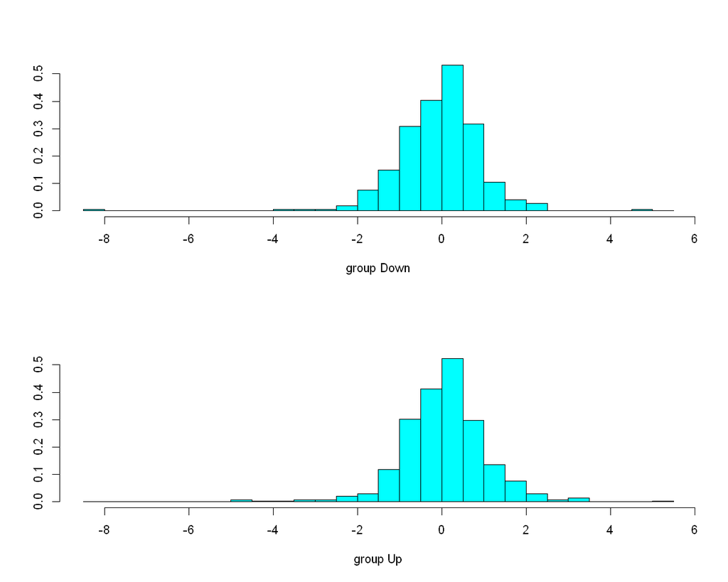

```r
#################################################################################################
# Appendix: Linear Discriminant Analysis - Using hold-out validation set and just Lag2 predictor
#################################################################################################
## Fit model
lda.model <- lda(Direction ~ Lag2, data=train.data)

## Summary
(lda.model)

## Plot
plot(lda.model)

paste("Prior, unconditioned probability of Down:", lda.model$prior[1])
paste("Prior, unconditioned probability of Up:", lda.model$prior[2])

## Prediction
lda.predictions <- predict(lda.model, test.data)

# Testing Confusion matrix
# Confusion matrix
(test.table <- table("Actual"=test.data$Direction, "Preds"=lda.predictions$class))

# Classificaiton metrics
paste("Testing - Correct Classification Rate: ", (test.table[1,1]+test.table[2,2])/(nrow(test.data)))
paste("Testing - Misclassification Rate: ", 1-(test.table[1,1]+test.table[2,2])/(nrow(test.data)))
paste("Testing - Specificity: ", (test.table[1,1])/(test.table[1,1]+test.table[1,2]))
paste("Testing - Sensitvity: ", (test.table[2,2])/(test.table[2,2]+test.table[2,1]))
paste("Testing - Positive Predictive Value: ", (test.table[2,2])/(test.table[1,2]+test.table[2,2]))
paste("Testing - Negative Predictive Value: ", (test.table[1,1])/(test.table[1,1]+test.table[2,1]))
```

```r
#################################################################################################
# Appendix: Quadratic Discriminant Analysis - Using hold-out validation set and just Lag2 predictor
#################################################################################################
## Fit model
qda.model <- qda(Direction ~ Lag2, data=train.data)

## Summary
(qda.model)

paste("Prior, unconditioned probability of Down:", qda.model$prior[1])
paste("Prior, unconditioned probability of Up:", qda.model$prior[2])

## Training Fit
lda.prediction <- predict(qda.model, train.data)

# Training Confusion matrix
table("Actual"=train.data$Direction, "Preds"=lda.prediction$class)

## Test Prediction
lda.prediction <- predict(qda.model, test.data)

# Testing Confusion matrix
(test.table <- table("Actual"=test.data$Direction, "Preds"=lda.prediction$class))

# Classificaiton metrics
paste("Testing - Correct Classification Rate: ", (test.table[1,1]+test.table[2,2])/(nrow(test.data)))
paste("Testing - Misclassification Rate: ", 1-(test.table[1,1]+test.table[2,2])/(nrow(test.data)))
paste("Testing - Specificity: ", (test.table[1,1])/(test.table[1,1]+test.table[1,2]))
paste("Testing - Sensitvity: ", (test.table[2,2])/(test.table[2,2]+test.table[2,1]))
paste("Testing - Positive Predictive Value: ", (test.table[2,2])/(test.table[1,2]+test.table[2,2]))
paste("Testing - Negative Predictive Value: ", (test.table[1,1])/(test.table[1,1]+test.table[2,1]))
```

```
Call:
qda(Direction ~ Lag2, data = train.data)

Prior probabilities of groups:
     Down        Up
0.4477157 0.5522843

Group means:
            Lag2
Down -0.07205722
Up    0.05841404
```

'Prior, unconditioned probability of Down: 0.447715736040609'

'Prior, unconditioned probability of Up: 0.552284263959391'

```
      Preds
Actual Down  Up
  Down    0 441
  Up      0 544
```

```
      Preds
Actual Down Up
  Down    0 43
  Up      0 61
```

'Testing - Correct Classification Rate: 0.586538461538462'

'Testing - Misclassification Rate: 0.413461538461538'

'Testing - Specificity: 0'

'Testing - Sensitvity: 1'

'Testing - Positive Predictive Value: 0.586538461538462'

'Testing - Negative Predictive Value: NaN'

```r
#################################################################################################
# Appendix: k-Nearest Neighbors Classification - Using hold-out validation set and just Lag2 predictor
#################################################################################################
## Fit model
train.X <- as.data.frame(train.data$Lag2)
test.X <- as.data.frame(test.data$Lag2)
train.Direction <- (train.data$Direction)

knn.model <- knn(train=train.X,test=test.X,cl=train.Direction,k=1)

# Testing Confusion matrix
(test.table <- table("Actual"=test.data$Direction, "Preds"=knn.model))

# Classificaiton metrics
paste("Testing - Correct Classification Rate: ", (test.table[1,1]+test.table[2,2])/(nrow(test.data)))
paste("Testing - Misclassification Rate: ", 1-(test.table[1,1]+test.table[2,2])/(nrow(test.data)))
paste("Testing - Specificity: ", (test.table[1,1])/(test.table[1,1]+test.table[1,2]))
paste("Testing - Sensitvity: ", (test.table[2,2])/(test.table[2,2]+test.table[2,1]))
paste("Testing - Positive Predictive Value: ", (test.table[2,2])/(test.table[1,2]+test.table[2,2]))
paste("Testing - Negative Predictive Value: ", (test.table[1,1])/(test.table[1,1]+test.table[2,1]))
```

```
      Preds
Actual Down Up
  Down   14 29
  Up     26 35
```

'Testing - Correct Classification Rate: 0.471153846153846'

'Testing - Misclassification Rate: 0.528846153846154'

'Testing - Specificity: 0.325581395348837'

'Testing - Sensitvity: 0.573770491803279'

'Testing - Positive Predictive Value: 0.546875'

'Testing - Negative Predictive Value: 0.35'

```r
#################################################################################################
# Appendix: Logistic Regression - Using hold-out validation set and various predictors
#################################################################################################
## Fit model
logistic.regression <- glm(Direction∼ Lag1:Lag3 + Lag2 + Lag3 +
                           Volume.Lag2:Volume.Lag3 + Volume.Lag2:Lag5,
                           data=train.data, family=binomial)
# Summary
(summary(logistic.regression))

# Testing Prediction
logistic.prediction.probs <- predict(logistic.regression, test.data, type="response")
logistic.predictions <- rep("Down",nrow(test.data))
logistic.predictions[logistic.prediction.probs>.5]="Up"

# Testing Confusion matrix
(test.table <- table("Actual"=test.data$Direction, "Preds"=logistic.predictions))

# Classificaiton metrics
paste("Testing - Correct Classification Rate: ", (test.table[1,1]+test.table[2,2])/(nrow(test.data)))
paste("Testing - Misclassification Rate: ", 1-(test.table[1,1]+test.table[2,2])/(nrow(test.data)))
paste("Testing - Specificity: ", (test.table[1,1])/(test.table[1,1]+test.table[1,2]))
paste("Testing - Sensitvity: ", (test.table[2,2])/(test.table[2,2]+test.table[2,1]))
paste("Testing - Positive Predictive Value: ", (test.table[2,2])/(test.table[1,2]+test.table[2,2]))
paste("Testing - Negative Predictive Value: ", (test.table[1,1])/(test.table[1,1]+test.table[2,1]))
```

```
Call:
glm(formula = Direction ~ Lag1:Lag3 + Lag2 + Lag3 + Volume.Lag2:Volume.Lag3 +
    Volume.Lag2:Lag5, family = binomial, data = train.data)

Deviance Residuals:
   Min      1Q  Median      3Q     Max
-1.542  -1.265   1.014   1.087   1.573

Coefficients:
                         Estimate Std. Error z value Pr(>|z|)
(Intercept)              0.238191   0.071579   3.328 0.000876 ***
Lag2                     0.052842   0.029681   1.780 0.075023 .
Lag3                    -0.018915   0.029857  -0.633 0.526408
Lag1:Lag3                0.015800   0.010016   1.577 0.114691
Volume.Lag2:Volume.Lag3 -0.012389   0.010992  -1.127 0.259686
Volume.Lag2:Lag5         0.007407   0.010020   0.739 0.459772
---
Signif. codes:  0 '***' 0.001 '**' 0.01 '*' 0.05 '.' 0.1 ' ' 1

(Dispersion parameter for binomial family taken to be 1)

    Null deviance: 1354.7  on 984  degrees of freedom
Residual deviance: 1345.9  on 979  degrees of freedom
AIC: 1357.9

Number of Fisher Scoring iterations: 4
```

```
      Preds
Actual Down Up
  Down   26 17
  Up     23 38
```

'Testing - Correct Classification Rate: 0.615384615384615'

'Testing - Misclassification Rate: 0.384615384615385'

'Testing - Specificity: 0.604651162790698'

'Testing - Sensitvity: 0.622950819672131'

'Testing - Positive Predictive Value: 0.690909090909091'

'Testing - Negative Predictive Value: 0.530612244897959'

```
Call:
lda(Direction ~ Lag1:Lag3 + Lag2 + Lag3 + Volume.Lag2:Volume.Lag3 +
    Volume.Lag2:Lag5, data = train.data)

Prior probabilities of groups:
     Down        Up
0.4477157 0.5522843

Group means:
            Lag2       Lag3    Lag1:Lag3 Volume.Lag2:Volume.Lag3
Down -0.03568254 0.17080045 -0.006554329                3.225198
Up    0.26036581 0.08404044  0.687742739                2.621278
     Volume.Lag2:Lag5
Down       -0.4049084
Up         -0.1628602

Coefficients of linear discriminants:
                                LD1
Lag2                     0.27362634
Lag3                    -0.09023887
Lag1:Lag3                0.07376334
Volume.Lag2:Volume.Lag3 -0.06317386
Volume.Lag2:Lag5         0.03905750
```

'Prior, unconditioned probability of Down: 0.447715736040609'

'Prior, unconditioned probability of Up: 0.552284263959391'

```
      Preds
Actual Down Up
  Down   26 17
  Up     22 39
```

'Testing - Correct Classification Rate: 0.625'

'Testing - Misclassification Rate: 0.375'

'Testing - Specificity: 0.604651162790698'

'Testing - Sensitvity: 0.639344262295082'

'Testing - Positive Predictive Value: 0.696428571428571'

'Testing - Negative Predictive Value: 0.541666666666667'

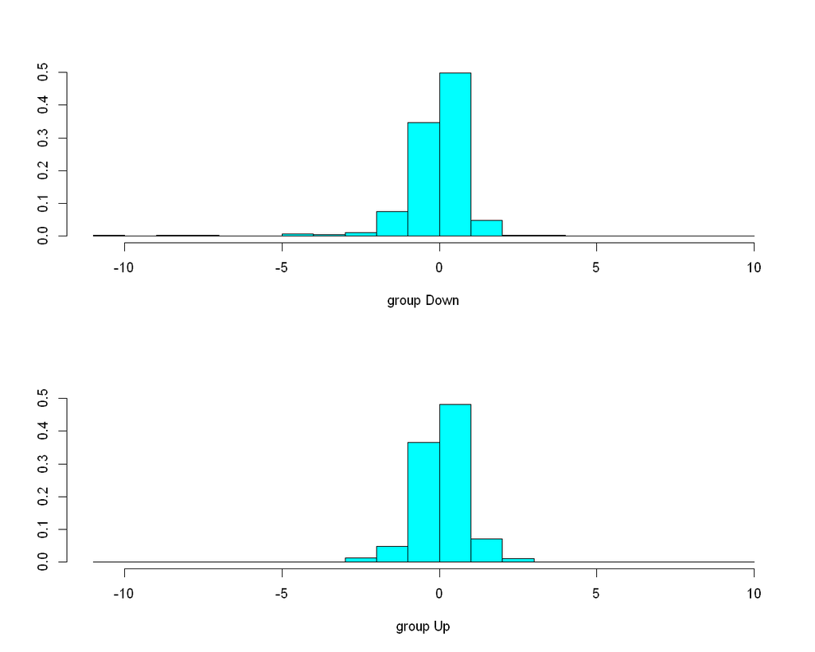

```r
#################################################################################################
# Appendix: Linear Discriminant Analysis - Using hold-out validation set and various predictors
#################################################################################################
## Fit model
lda.model <- lda(Direction ∼ Lag1:Lag3 + Lag2 + Lag3 +
                 Volume.Lag2:Volume.Lag3 + Volume.Lag2:Lag5, data=train.data)

## Summary
(lda.model)

## Plot
plot(lda.model)

paste("Prior, unconditioned probability of Down:", lda.model$prior[1])
paste("Prior, unconditioned probability of Up:", lda.model$prior[2])

## Prediction
lda.predictions <- predict(lda.model, test.data)

# Testing Confusion matrix
# Confusion matrix
(test.table <- table("Actual"=test.data$Direction, "Preds"=lda.predictions$class))

# Classificaiton metrics
paste("Testing - Correct Classification Rate: ", (test.table[1,1]+test.table[2,2])/(nrow(test.data)))
paste("Testing - Misclassification Rate: ", 1-(test.table[1,1]+test.table[2,2])/(nrow(test.data)))
paste("Testing - Specificity: ", (test.table[1,1])/(test.table[1,1]+test.table[1,2]))
paste("Testing - Sensitvity: ", (test.table[2,2])/(test.table[2,2]+test.table[2,1]))
paste("Testing - Positive Predictive Value: ", (test.table[2,2])/(test.table[1,2]+test.table[2,2]))
paste("Testing - Negative Predictive Value: ", (test.table[1,1])/(test.table[1,1]+test.table[2,1]))
```

```r
#################################################################################################
# Appendix: Quadratic Discriminant Analysis - Using hold-out validation set and various predictors
#################################################################################################
## Fit model
qda.model <- qda(Direction ~ Lag2 + Lag1:Lag3 + Lag1:Lag5 +
                 Sequence*Volume + diff.lag1.lag2 + diff.lag1.lag3, data=train.data)

## Summary
(qda.model)

paste("Prior, unconditioned probability of Down:", qda.model$prior[1])
paste("Prior, unconditioned probability of Up:", qda.model$prior[2])

## Training Fit
lda.prediction <- predict(qda.model, train.data)

# Training Confusion matrix
table("Actual"=train.data$Direction, "Preds"=lda.prediction$class)

## Test Prediction
lda.prediction <- predict(qda.model, test.data)

# Testing Confusion matrix
(test.table <- table("Actual"=test.data$Direction, "Preds"=lda.prediction$class))

# Classificaiton metrics
paste("Testing - Correct Classification Rate: ", (test.table[1,1]+test.table[2,2])/(nrow(test.data)))
paste("Testing - Misclassification Rate: ", 1-(test.table[1,1]+test.table[2,2])/(nrow(test.data)))
paste("Testing - Specificity: ", (test.table[1,1])/(test.table[1,1]+test.table[1,2]))
paste("Testing - Sensitvity: ", (test.table[2,2])/(test.table[2,2]+test.table[2,1]))
paste("Testing - Positive Predictive Value: ", (test.table[2,2])/(test.table[1,2]+test.table[2,2]))
paste("Testing - Negative Predictive Value: ", (test.table[1,1])/(test.table[1,1]+test.table[2,1]))
```

```
Call:
qda(Direction ~ Lag2 + Lag1:Lag3 + Lag1:Lag5 + Sequence * Volume +
    diff.lag1.lag2 + diff.lag1.lag3, data = train.data)

Prior probabilities of groups:
     Down        Up
0.4477157 0.5522843

Group means:
            Lag2 Sequence   Volume diff.lag1.lag2 diff.lag1.lag3    Lag1:Lag3
Down -0.03568254 505.1111 1.266240       0.325127     0.11864399 -0.006554329
Up    0.26036581 483.1820 1.151442      -0.269579    -0.09325368  0.687742739
      Lag1:Lag5 Sequence:Volume
Down  0.3615693        950.5974
Up   -0.1833118        836.3069
```

'Prior, unconditioned probability of Down: 0.447715736040609'

'Prior, unconditioned probability of Up: 0.552284263959391'

```
      Preds
Actual Down  Up
  Down   69 372
  Up     61 483
```

```
      Preds
Actual Down Up
  Down   29 14
  Up     26 35
```

'Testing - Correct Classification Rate: 0.615384615384615'

'Testing - Misclassification Rate: 0.384615384615385'

'Testing - Specificity: 0.674418604651163'

'Testing - Sensitvity: 0.573770491803279'

'Testing - Positive Predictive Value: 0.714285714285714'

'Testing - Negative Predictive Value: 0.527272727272727'

```r
#################################################################################################
# Appendix: k-Nearest Neighbors Classification - Using hold-out validation set and various predictors
#################################################################################################
## Fit model
knn.predictors <- c('diff.lag1.lag2', 'diff.lag1.lag4', 'Volume.Lag5',
                    'sq.diff.lag1.lag5', 'Volume.Lag4')
train.X <- (as.data.frame(train.data[knn.predictors]))
test.X <- as.data.frame(test.data[knn.predictors])
train.Direction <- (train.data$Direction)

knn.model <- knn(train=train.X,test=test.X,cl=train.Direction,k=1)

# Testing Confusion matrix
(test.table <- table("Actual"=test.data$Direction, "Preds"=knn.model))

# Classificaiton metrics
paste("Testing - Correct Classification Rate: ", (test.table[1,1]+test.table[2,2])/(nrow(test.data)))
paste("Testing - Misclassification Rate: ", 1-(test.table[1,1]+test.table[2,2])/(nrow(test.data)))
paste("Testing - Specificity: ", (test.table[1,1])/(test.table[1,1]+test.table[1,2]))
paste("Testing - Sensitvity: ", (test.table[2,2])/(test.table[2,2]+test.table[2,1]))
paste("Testing - Positive Predictive Value: ", (test.table[2,2])/(test.table[1,2]+test.table[2,2]))
paste("Testing - Negative Predictive Value: ", (test.table[1,1])/(test.table[1,1]+test.table[2,1]))
```

```
      Preds
Actual Down Up
  Down   30 13
  Up     23 38
```

'Testing - Correct Classification Rate: 0.653846153846154'

'Testing - Misclassification Rate: 0.346153846153846'

'Testing - Specificity: 0.697674418604651'

'Testing - Sensitvity: 0.622950819672131'

'Testing - Positive Predictive Value: 0.745098039215686'

'Testing - Negative Predictive Value: 0.566037735849057'